# Weather Events and its Economic and Health Impact across the United States

Raymark Parocha

7/24/2020

## Synopsis

This is the second course project and last requirement of the Reproducible Research course. For this requirement, the goal is to assess the storm database of US National Oceanic and Atmospheric Administration (NOAA). In particular, the impact of severe weather events on both economy (property and crop damages) and health (injuries and fatalities) are to be examined.

In addition, it is also important to note that the storm database spans from 1950 until November 2011. The data documentation of this data can be accessed in this [Link](https://d396qusza40orc.cloudfront.net/repdata%2Fpeer2_doc%2Fpd01016005curr.pdf)

## Data Processing

### Section 1: Importing libraries and downloading the raw data

Import the libraries that will be used in the analysis.

```r
library("data.table")
library("ggplot2")
```

Download the raw data from NOAA and assign it to a data table.

```r
download.file("https://d396qusza40orc.cloudfront.net/repdata%2Fdata%2FStormData.csv.bz2",
              destfile = paste0(getwd(), '/repdata%2Fdata%2FStormData.csv.bz2'), mode="wb")

stormDataFrame <- read.csv("repdata%2Fdata%2FStormData.csv.bz2")

# Converting data.frame to data.table
stormDataTable <- as.data.table(stormDataFrame)
```

### Section 2: Inspect column names before subsetting

Inspect the column names of the data table that are relevant to the analysis.

```r
colnames(stormDataTable)
```

```
##  [1] "STATE__"    "BGN_DATE"   "BGN_TIME"   "TIME_ZONE"  "COUNTY"
##  [6] "COUNTYNAME" "STATE"      "EVTYPE"     "BGN_RANGE"  "BGN_AZI"
## [11] "BGN_LOCATI" "END_DATE"   "END_TIME"   "COUNTY_END" "COUNTYENDN"
## [16] "END_RANGE"  "END_AZI"    "END_LOCATI" "LENGTH"     "WIDTH"
## [21] "F"          "MAG"        "FATALITIES" "INJURIES"   "PROPDMG"
## [26] "PROPDMGEXP" "CROPDMG"    "CROPDMGEXP" "WFO"        "STATEOFFIC"
## [31] "ZONENAMES"  "LATITUDE"   "LONGITUDE"  "LATITUDE_E" "LONGITUDE_"
## [36] "REMARKS"    "REFNUM"
```

### Section 3: Subsetting data

Upon checking the column names, the relevant variables for Health and Economy are as follows.

Health variables: 1. FATALITIES refer to the approximate number of deaths. 2. INJURIES refer to the approximate number of injuries.

Economic variables: 1. PROPDMG refers to the approximate property damages 2. PROPDMGEXP refers to the value of property damages 3. CROPDMG refers to the approximate crop damages 4. CROPDMGEXP refers to the value of crop damages

```r
# Restructuring the Data table to remove unnecessary columns
columnsOfinterest <- colnames(stormDataTable[, !c("EVTYPE", "FATALITIES", "INJURIES", "PROPDMG", "PROPDMGEXP", "CROPDMG", "CROPDMGEXP")])

stormDataTable[, c(columnsOfinterest) := NULL]

# Remove incidents where the effect of the storm is negligible.
stormDataTable <- stormDataTable[(EVTYPE != "?" & (INJURIES > 0 | FATALITIES > 0 | PROPDMG > 0 | CROPDMG > 0)), c("EVTYPE", "FATALITIES", "INJURIES", "PROPDMG", "PROPDMGEXP", "CROPDMG", "CROPDMGEXP") ]
```

```r
# Checking the restructured data table
tail(stormDataTable, 10)
```

```
##             EVTYPE FATALITIES INJURIES PROPDMG PROPDMGEXP CROPDMG CROPDMGEXP
##  1:    STRONG WIND          0        0    25.0          K       0          K
##  2:    STRONG WIND          0        0     2.0          K       0          K
##  3: WINTER WEATHER          0        0     5.0          K       0          K
##  4: WINTER WEATHER          0        0     5.0          K       0          K
##  5:   WINTER STORM          0        0     2.0          K       0          K
##  6:   WINTER STORM          0        0     5.0          K       0          K
##  7:    STRONG WIND          0        0     0.6          K       0          K
##  8:    STRONG WIND          0        0     1.0          K       0          K
##  9:        DROUGHT          0        0     2.0          K       0          K
## 10:      HIGH WIND          0        0     7.5          K       0          K
```

### Section 4: Convert prefixes of PROPDMGEXP and CROPDMGEXP to their actual multiplier

From the restructured data table, it can be seen that PROPDMGEXP and CROPDMGEXP have prefixes that actually denote a multiplier value to the power of 10. It is important to convert these prefixes to calculate the actual cost of property and crop damages.

```r
# First, it is important that all damage exponents are in uppercase.
cols <- c("PROPDMGEXP", "CROPDMGEXP")
stormDataTable[,  (cols) := c(lapply(.SD, toupper)), .SDcols = cols]

# Convert the alphanumeric symbols to their corresponding power of 10 numeric values.

# For the Property Damages Multiplier (PROPDMGEXP)
prefixProp <-  c("\"\"" = 10^0, "-" = 10^0, "+" = 10^0, "0" = 10^0, "1" = 10^1, "2" = 10^2, "3" = 10^3, "4" = 10^4, "5" = 10^5, "6" = 10^6, "7" = 10^7, "8" = 10^8, "9" = 10^9, "H" = 10^2, "K" = 10^3, "M" = 10^6, "B" = 10^9)
stormDataTable[, PROPDMGEXP := prefixProp[as.character(stormDataTable[,PROPDMGEXP])]]
stormDataTable[is.na(PROPDMGEXP), PROPDMGEXP := 10^0 ]

# For the Crop Damages Multiplier (CROPDMGEXP)
prefixCrop <-  c("\"\"" = 10^0, "?" = 10^0, "0" = 10^0, "K" = 10^3, "M" = 10^6,"B" = 10^9)
stormDataTable[, CROPDMGEXP := prefixCrop[as.character(stormDataTable[,CROPDMGEXP])] ]
stormDataTable[is.na(CROPDMGEXP), CROPDMGEXP := 10^0 ]
```

### Section 5: Creating a data table for the total property and crop damages inflicted by each event

Two additional columns were created which was the result of the multiplication of PROPDMG and its multiplier PROPDMGEXP

```r
# Creating two additional columns for the actual value for Crop Damage and Property Damage
stormDataTable <- stormDataTable[, .(EVTYPE, FATALITIES, INJURIES, PROPDMG, PROPDMGEXP, PROPERTY = PROPDMG * PROPDMGEXP, CROPDMG, CROPDMGEXP, CROPS = CROPDMG * CROPDMGEXP)]
```

For this part, a new data table was created that sums up the total property and crop damages incurred by various events.

```r
PropCropCost <- stormDataTable[, .(PROPERTY = sum(PROPERTY), CROPS = sum(CROPS), TOTALCOST = sum(PROPERTY) + sum(CROPS)), by = .(EVTYPE)]

PropCropCost <- PropCropCost[order(-TOTALCOST), ]
PropCropCost <- PropCropCost[1:10, ]

head(PropCropCost, 10)
```

```
##                EVTYPE     PROPERTY       CROPS    TOTALCOST
##  1:             FLOOD 144657709807  5661968450 150319678257
##  2: HURRICANE/TYPHOON  69305840000  2607872800  71913712800
##  3:           TORNADO  56947380677   414953270  57362333947
##  4:       STORM SURGE  43323536000        5000  43323541000
##  5:              HAIL  15735267513  3025954473  18761221986
##  6:       FLASH FLOOD  16822673979  1421317100  18243991079
##  7:           DROUGHT   1046106000 13972566000  15018672000
##  8:         HURRICANE  11868319010  2741910000  14610229010
##  9:       RIVER FLOOD   5118945500  5029459000  10148404500
## 10:         ICE STORM   3944927860  5022113500   8967041360
```

### Section 6: Creating a data table for the total fatalities and injuries inflicted by each event

```r
Casualties <- stormDataTable[, .(FATALITIES = sum(FATALITIES), INJURIES = sum(INJURIES), TOTALCASUALTY = sum(FATALITIES) + sum(INJURIES)), by = .(EVTYPE)]

Casualties <- Casualties[order(-TOTALCASUALTY), ]

Casualties <- Casualties[1:10, ]

head(Casualties, 10)
```

```
##                EVTYPE FATALITIES INJURIES TOTALCASUALTY
##  1:           TORNADO       5633    91346         96979
##  2:    EXCESSIVE HEAT       1903     6525          8428
##  3:         TSTM WIND        504     6957          7461
##  4:             FLOOD        470     6789          7259
##  5:         LIGHTNING        816     5230          6046
##  6:              HEAT        937     2100          3037
##  7:       FLASH FLOOD        978     1777          2755
##  8:         ICE STORM         89     1975          2064
##  9: THUNDERSTORM WIND        133     1488          1621
## 10:      WINTER STORM        206     1321          1527
```

## Results

### Section 1: Analyzing which events resulted to damages to population health

In this section, a bar chart was constructed to visually see which event had the most damages among US citizens from 1950 until November 2011.

From the bar chart below, it can be seen that majority of event-based casualty in the United States were caused by tornadoes. Other events do not contribute as much which means citizens should prepare measures to counter the effects of upcoming tornadoes.

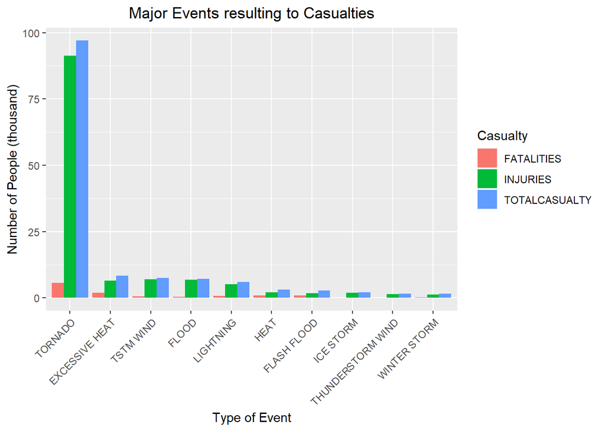

```r
casualties <- melt(Casualties, id.vars="EVTYPE", variable.name = "Casualty")

# Creating a Bar Chart
casualtyGraph<- ggplot(casualties, aes(x=reorder(EVTYPE, -value), y=value/10^3)) +
                      geom_bar(stat="identity", aes(fill=Casualty), position="dodge") +
                      xlab("Type of Event") +
                      ylab("Number of People (thousand)") +
                      theme(axis.text.x = element_text(angle=45, hjust=1))+
                      ggtitle("Major Events resulting to Casualties") +
                      theme(plot.title = element_text(hjust = 0.5))
casualtyGraph
```

### Section 2: Analyzing which events resulted to greatest economic consequences

In this section, a bar chart was constructed to summarized which storm event incurred most damages in US dollars in terms of property and crop damages.

It can be seen from the graph that floods are top contributor to damage cost to property and crops. After the effects brought about by floods, disasters such as hurricane, tornado and storm surge also imposed major damages to property and crops in the United States for the past 60 years according to the data.

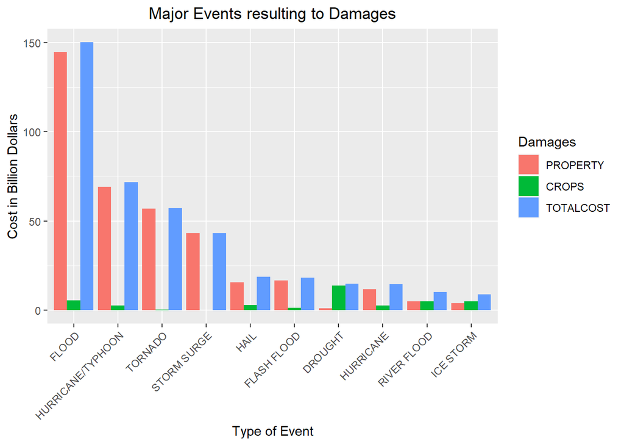

```r
propcropEcon <- melt(PropCropCost, id.vars="EVTYPE", variable.name = "Damages")

# Creating a Bar chart
economyGraph <- ggplot(propcropEcon, aes(x=reorder(EVTYPE, -value), y=value/10^9)) +
                      geom_bar(stat="identity", aes(fill=Damages), position="dodge") +
                      ylab("Cost in Billion Dollars") +
                      xlab("Type of Event") +
                      theme(axis.text.x = element_text(angle=45, hjust=1)) +
                      ggtitle("Major Events resulting to Damages") +
                      theme(plot.title = element_text(hjust = 0.5))

economyGraph
```